# DSI_Lab_4

Dingxin Lu

11/10/2021

[My github link] https://github.com/sydneydlu98/DSI_Lab_4

**Collaborated with Peizheng Chen and Yike Zhang.**

```r
## load all the library
library(fields)
library(readr)
library(tidyverse)
library(GGally)
```

# Problem 1

Write your own k-means clustering function

- Name your function k_means
- This function should have three arguments:
  - data for the dataset to be clustered
  - k for the number of clusters k
  - iter for the number of iterations performed
- In your function, start by randomly assigning each observation to a cluster and calculate the centroids for each of the cluster
- In the loop (loop through for the number of iterations)
  - Calculate the distance from each point to each of the centroids (Hint: I used fields::rdist for this)
  - Calculate the minimum distance for each point to the centroids (Hint: I used an apply statement with which.min)
  - Calculate the new centroids (and then repeat!)
- Return the cluster assignments for each of the observations in the dataset
- Don’t forget to set a seed!

```r
# set seed
set.seed(100)

# set function k_means
# data for the dataset to be clustered
# k for the number of clusters k
#iter for the number of iterations performed
k_means <- function(data, k, iter) {

  # randomly assigning each observation to a cluster
  data_cluster <- data %>%
    mutate(cluster = sample(1:k,
                            nrow(data),
                            replace = TRUE))

  # calculate the centroids for each of the cluster
  centroids <- data_cluster %>%
    group_by(cluster) %>%
    summarise(across(everything(),
                     mean))

  # each point in the dataset
  point <- data_cluster %>%
    select(-cluster)

  # loop through for the number of iterations
  for (i in 1:iter) {

    # Calculate the distance from each point to each of the centroids
    distsToCenters <- rdist(centroids[,-1],
                            point)

    # Calculate the minimum distance for each point to the centroids
    minDis <- apply(distsToCenters,
                    2,
                    which.min)

    # Calculate the new centroids
    # and repeat
    data %>%
      mutate(cluster = minDis) %>%
      group_by(cluster) %>%
      summarise(across(everything(),
                       mean))
  }

  # Return the cluster assignments for each of the observations
  return(minDis)
}
```

# Problem 2

Cluster the iris dataset (Hint: Don’t forget to scale the data before you cluster!) using your function k_means. Try this with 3 clusters. Use GGally:ggpairs to visualize the four variables colored by your cluster assignment.

```r
# set seed
set.seed(100)

# adjustment for dataset iris
iris_new <- iris %>%
  select(-Species)

# scale the dataset iris
scaled_iris <- scale(iris_new)

# cluster the iris dataset
# cluster the dataset with 3 clusters and 50 iterations
iris_kmean <- k_means(as.data.frame(scaled_iris), 3, 50)
iris_kmean
```

```
##   [1] 1 1 1 1 1 1 1 1 1 1 1 1 1 1 1 1 1 1 1 1 1 1 1 1 1 1 1 1 1 1 1 1 1 1 1 1 1
##  [38] 1 1 1 1 3 1 1 1 1 1 1 1 1 2 2 2 3 2 3 2 3 2 3 3 2 3 2 3 2 2 3 2 3 2 2 2 2
##  [75] 2 2 2 2 2 3 3 3 3 2 3 2 2 2 3 3 3 2 3 3 3 3 3 2 3 3 2 2 2 2 2 2 3 2 2 2 2
## [112] 2 2 2 2 2 2 2 2 2 2 2 2 2 2 2 2 2 2 2 2 2 2 2 2 2 2 2 2 2 2 2 2 2 2 2 2 2
## [149] 2 2
```

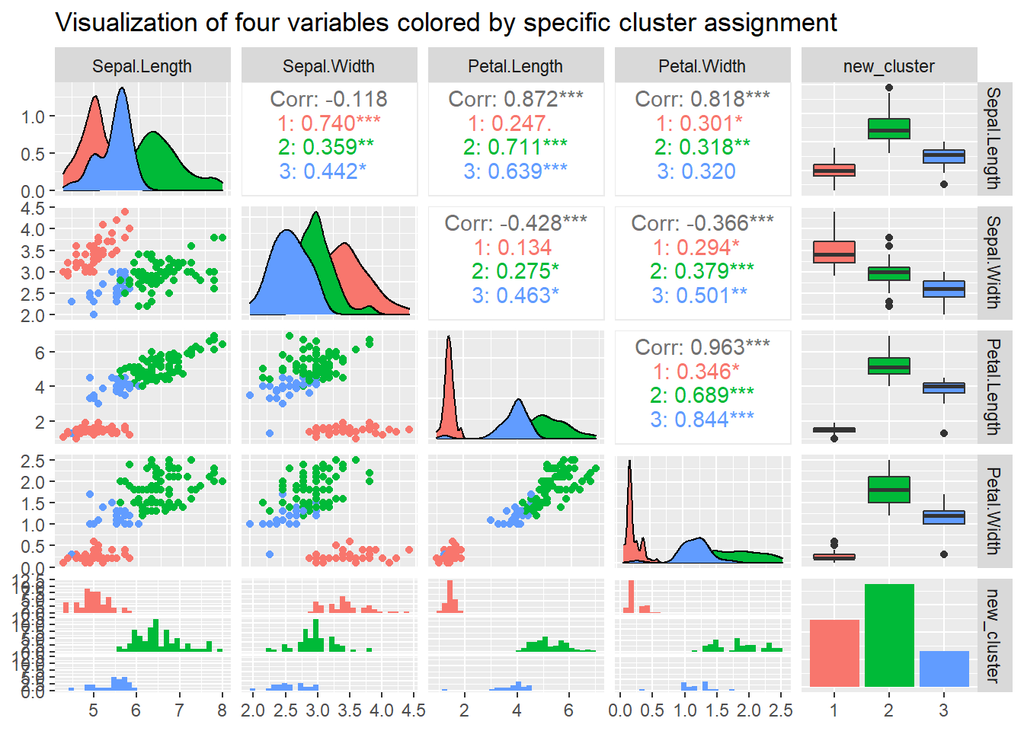

```r
# adjust the dataset for visualization
iris_final <- iris_new %>%
  mutate(new_cluster = as.factor(iris_kmean))

# visualize the four variables colored by your cluster assignment
ggpairs(iris_final,
        ggplot2::aes(colour = new_cluster),
        title = "Visualization of four variables colored by specific cluster assignment")
```

# Problem 3

Using the code from the lecture notes and the kmeans function in R, produce the associated elbow plot (i.e., a plot of within-cluster sum of squares vs. cluster size). Given your plot, what is the appropriate number of clusters for the iris dataset? Why?

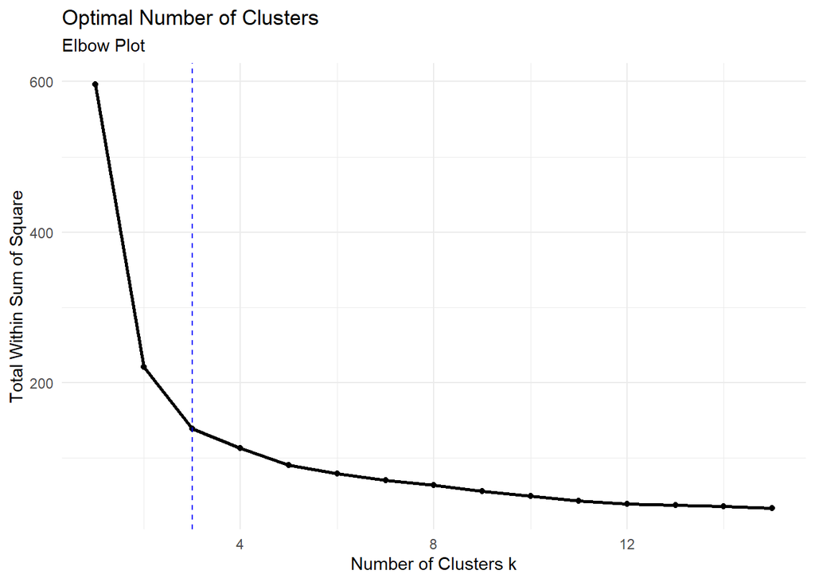

```r
# set seed
set.seed(100)

# function for Total Within Sum of Square (WSS)
wss <- function(k, data) {
  kmeans(data, k, nstart = 10)$tot.withinss
}

# examining the total within-cluster sum of squares
# for different numbers of clusters
# (1 through 15 here)
k_values <- 1:15

wss_values <- map_dbl(k_values, wss,
                      data = scaled_iris)

wss_values <- data.frame(wss = wss_values,
                         k = k_values)

# produce the associated elbow plot
ggplot(wss_values,
       aes(x = k,
           y = wss)) +
  geom_point() +
  geom_line(lwd = 1) +
  # add line for better visualization
  geom_vline(xintercept = 3,
             linetype = 2,
             col = "blue") +
  theme_minimal() +
  labs(
    x = "Number of Clusters k",
    y = "Total Within Sum of Square",
    title = "Optimal Number of Clusters",
    subtitle = "Elbow Plot"
  )
```

The optimal number of clusters for this data set should be 3 (demonstrated in the plot). Because when number of clusters k is 3 and onwards, the total within sum of square reduces slowly, so we would know 3 is the optimal number of clusters.